# Coding Lab Final Project

Jacob Jameson

Your final project is quite simple. You will pick a data set that speaks to you and try to uncover something interesting which you will visualize in a plot. You will also compute some summary statistics that you will show in a summary table. Your TAs will review your work.

#### Suggested due date: September 22, 5pm CDT upload your Rmd and knitted PDF/HTML to Gradescope. Feel free to submit your work earlier.

### Format:

You will turn in a knitted PDF or HTML that has the following sections.

- `graph` in which you load your data set and provide the minimal code that produces your graph.
- `table` in which you create and print a summary table with minimal code.
- `appendix` (optional) in which you share code you used during data exploration, e.g. extensions of your main plot, other plots you attempted on your search for your main plot.

I have provided a sample project at the end of this document. You are welcome to use google and stackoverflow as you procede. Please cite your sources if you borrow code from stackoverflow or someone’s blog. To cite, just add a comment with the url.

Here are some quick tips:

- You make a new section in Rmd using `# section title`.
- When you read in you data, we do not want to see messages or warnings. To avoid this start the code block where you read the data with the following `{r, message = FALSE, warning = FALSE}`.
- If you have a line of code that is too long, it will be cutoff. Most R code can be split across two lines.
- Knit early and often! This is how you know if the Rmd is working how you think it is.

### Datasets:

Below is a list of suitable data sources. You are welcome to and encouraged to find a data source not on this list that speaks to your policy interests. Many of these data sources have a wide range of data sets. Pick one that comes in tabular format with several variables that are interesting. I recommend that once you pick a data source that is sufficient stick with it, so you have ample time to focus on your R skills.

[output not shown]

## Example project:

### Introduction

The Medical Expenditure Panel Survey (MEPS) provides nationally representative estimates of health care use, expenditures, sources of payment, and health insurance coverage for the U.S. civilian non-institutionalized population. I use this data from the 2019 survey to analyze disparities in dental care for children according to race and poverty status.

### **Do not be intimidated by how much I did for this example. I chose to use data that was more difficult to work with. There were also plenty of things I didn’t know exactly how to do until I googled them. I put those links that helped me when I was stuck under references. Your analysis does not need to be this complicated, especially if you choose easier data to work with. This is an opportunity for you to learn by doing– the goal is for it to be both useful and fun!**

**Also, note that only 2 of my code chunks even involve me manipulating the data. The other code chunks are for making a table (yours does not need to be this fancy) and for my plots (note that the code for plot 1 and plot 2 is almost exactly identical).**

[The data description is found here.](https://meps.ahrq.gov/data_stats/download_data/pufs/h216/h216doc.pdf)

[The data can be downloaded in a variety of formats here.](https://meps.ahrq.gov/mepsweb/data_stats/download_data_files_detail.jsp?cboPufNumber=HC-216)

```r
# Load packages (need to run every session)
  library(tidyverse)
  library(foreign)
  library(gtsummary)
  library(gridExtra)

# Set working directory to location of data
  setwd("/Users/jacob/Downloads/Coding Lab Project")

# Load FYC file
  FYC <- read.dta("h216.dta", convert.factors = TRUE)
```

```r
# Define variables
# Children receiving dental care
  FYC <- FYC %>%
    mutate(
      child_2to17 = (1 < AGELAST & AGELAST < 18)*1,
      child_dental = ((DVTOT19 > 0) & (child_2to17 == 1))*1,
      child_dental = recode_factor(child_dental,
                     "1" = "One or more dental visits",
                     "0" = "No dental visits in past year"))
```

```r
# Rename poverty status
  FYC <- FYC %>%
    rename(poverty = POVCAT19)

# Create a more generalize race category
  FYC <- FYC %>%
     mutate(race = case_when(
      RACEV1X == "1 WHITE - NO OTHER RACE REPORTED" ~ "WHITE",
      RACEV1X == "2 BLACK - NO OTHER RACE REPORTED"   ~ "BLACK",
      RACEV1X == "4 ASIAN/NATV HAWAIIAN/PACFC ISL-NO OTH" ~ "ASIAN",
      TRUE ~ "OTHER"))
```

```r
# Define subgroup and calculate estimates in table
  FYC %>%
    subset(child_2to17 == 1) %>%
    select(race, child_dental, poverty) %>%
    tbl_summary(by = child_dental) %>%
    add_p(pvalue_fun = ~style_pvalue(.x, digits = 2)) %>%
    add_overall() %>% add_n() %>%
    modify_header(label ~ "**Variable**") %>%
    modify_caption("**Table 1. Patient Characteristics**") %>%
    bold_labels()
```

**Table 1. Patient Characteristics**

| **Variable** | **N** | **Overall**, N = 6,009<sup>1</sup> | **One or more dental visits**, N = 3,302<sup>1</sup> | **No dental visits in past year**, N = 2,707<sup>1</sup> | **p-value**<sup>2</sup> |
| --- | --- | --- | --- | --- | --- |
| race | 6,009 |  |  |  | <0.001 |
| ASIAN |  | 304 (5.1%) | 169 (5.1%) | 135 (5.0%) |  |
| BLACK |  | 990 (16%) | 447 (14%) | 543 (20%) |  |
| OTHER |  | 432 (7.2%) | 220 (6.7%) | 212 (7.8%) |  |
| WHITE |  | 4,283 (71%) | 2,466 (75%) | 1,817 (67%) |  |
| poverty | 6,009 |  |  |  | <0.001 |
| 1 POOR/NEGATIVE |  | 1,448 (24%) | 648 (20%) | 800 (30%) |  |
| 2 NEAR POOR |  | 448 (7.5%) | 235 (7.1%) | 213 (7.9%) |  |
| 3 LOW INCOME |  | 974 (16%) | 516 (16%) | 458 (17%) |  |
| 4 MIDDLE INCOME |  | 1,683 (28%) | 893 (27%) | 790 (29%) |  |
| 5 HIGH INCOME |  | 1,456 (24%) | 1,010 (31%) | 446 (16%) |  |

<sup>*1*</sup> n (%) <sup>*2*</sup> Pearson's Chi-squared test

According to our analysis there appears to be a statistically significant difference between the distribution of racial and income demographics for those that have had dental care in the last year compared to those without dental care.

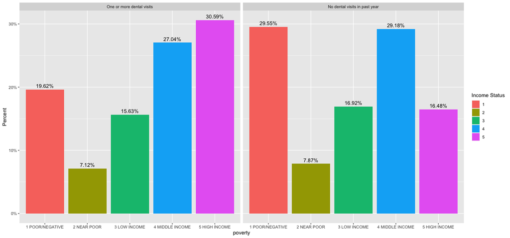

```r
FYC %>%
  subset(child_2to17 == 1) %>%
  ggplot(aes(x= poverty,  group=child_dental)) +
  geom_bar(aes(y = ..prop.., fill = factor(..x..)),
           stat="count") +
  geom_text(aes( label = scales::percent(..prop..),
                 y= ..prop.. ), stat= "count", vjust = -.5) +
  labs(y = "Percent", fill="Income Status") +
  facet_grid(~child_dental) +
  scale_y_continuous(labels = scales::percent)
```

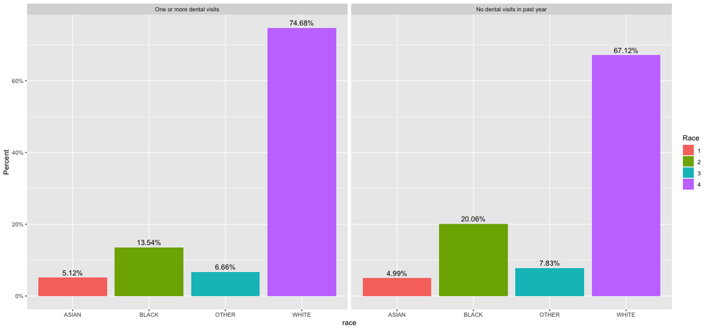

```r
FYC %>%
  subset(child_2to17 == 1) %>%
  ggplot(aes(x= race,  group=child_dental)) +
  geom_bar(aes(y = ..prop.., fill = factor(..x..)),
           stat="count") +
  geom_text(aes( label = scales::percent(..prop..),
                 y= ..prop.. ), stat= "count", vjust = -.5) +
  labs(y = "Percent", fill="Race") +
  facet_grid(~child_dental) +
  scale_y_continuous(labels = scales::percent)
```

### Code Referenced

- https://sebastiansauer.github.io/percentage_plot_ggplot2_V2/
- https://www.rdocumentation.org/packages/dplyr/versions/0.7.8/topics/case_when
- https://cran.r-project.org/web/packages/gtsummary/vignettes/tbl_summary.html